# Data Translation Question 1

Ami Kinnamon

3/16/2022

```r
knitr::opts_chunk$set(echo = TRUE)
```

# NOTES: THINGS TO ANSWER

1. Why you are running the analyses you are running
2. How the analyses answer the question being asked, and what the result is
3. Carefully interpreting the results
4. Presenting the results in an appealing way. Graphs are great, sumtable() is great, export_summs() is great - put a little effort into formatting tables and figures to make them look nice! At the very least, variable names should be in English rather than statistics-package (‘Education’ not ‘EDUC’). You will get marked down if variable names in your tables/graphs aren’t in English. If you aren’t comfortable enough with ggplot to make its visualizations look nice, feel free to make graphics in Excel or Tableau or anything you like, and include them in your RMarkdown doc as images. Econometric analyses should be in R, and code should be visible.
5. Acknowledging the assumptions you are making in each analysis, how plausible those assumptions are in the context of your data, and any evidence you can provide backing up those assumptions. Don’t forget this part, you will be marked down if you don’t do it.
6. After doing all analyses related to a given question, provide a generalized answer to the main questions.

# Question

How has COVID affected the health of the retail industry, as measured by employment?

# Loading Libraries

```r
library(ipumsr)
library(vtable)
library(tidyverse)
library(stringr)
library(lubridate)
library(jtools)
library(car)
library(knitr)
```

# Loading the IPUMS Data

```r
ddi <- read_ipums_ddi("cps_00003.xml")
data <- read_ipums_micro(ddi)
```

```
## Use of data from IPUMS CPS is subject to conditions including that users should
## cite the data appropriately. Use command `ipums_conditions()` for more details.
```

# Data Cleaning & Manipulation

## Adding Industry Names into the data

```r
# Joining the original data with indnames.csv
ind_df <- read_csv('indnames.csv')
ind_df <- rename(ind_df, IND = ind)
df <- left_join(data, ind_df, by = "IND")

# Looking at industry names and number of observations available
table(df$indname)
```

```
##
##                                    Agriculture, Forestry, Fishing, and Hunting, and Mining
##                                                                                     110682
##                   Arts, Entertainment, and Recreation, and Accommodation and Food Services
##                                                                                     374535
##                                                                               Construction
##                                                                                     294603
##                                Educational Services, and Health Care and Social Assistance
##                                                                                     937105
##                              Finance and Insurance, and Real Estate and Rental and Leasing
##                                                                                     270091
##                                                                                Information
##                                                                                      71279
##                                                                              Manufacturing
##                                                                                     392085
##                                                                                   Military
##                                                                                        549
##                                               Other Services, Except Public Administration
##                                                                                     198533
## Professional, Scientific, and Management, and Administrative and Waste Management Services
##                                                                                     485535
##                                                                      Public Administration
##                                                                                     209004
##                                                                               Retail Trade
##                                                                                     437032
##                                              Transportation and Warehousing, and Utilities
##                                                                                     222964
##                                                                            Wholesale Trade
##                                                                                      91152
```

## Filtering for specific characteristics

```r
# Filtering for January 2018 to present day to study employment before and after the onset of the pandemic
# Filtering to study Retail employment alone
retail <- df %>%
  filter(YEAR > 2017) %>%
  filter(indname == "Retail Trade")

# Filtering out the excess ASEC data to avoid extra observations for each March
# Converting the NA values (non-ASEC data) into a "0"
retail$ASECFLAG[is.na(retail$ASECFLAG)] <- 0

retail <- retail %>%
  filter(ASECFLAG != 1)
```

## Creating new variables

### EMPLOYED - Binary Variable for Employment Status

```r
table(retail$EMPSTAT)
```

```
##
##     10     12     21     32     34     36
## 269072   9702  15808    407   3034    989
```

```r
# Group together "10" and "12" as Employed
# Indicate "21" as Unemployed
# Drop "32", "34", and "36" for not being in the Labor Force

retail <- retail %>%
  filter(EMPSTAT < 30) %>%
  mutate(EMPLOYED = EMPSTAT != 21)
```

### YEAR_MONTH - Date Variable Combining Year and Month Together

```r
# Concatenating the YEAR and MONTH variable together
retail$YEAR_MONTH <- str_c(retail$YEAR, "-", retail$MONTH)

# Using package lubridate to render the variable as a Date type
retail <- retail %>%
  mutate(YEAR_MONTH = ym(YEAR_MONTH))
```

### POC - Binary Variable for RACE (whether or not the subject is a Person of Color)

```r
# TRUE for Person of Color (including those who are mixed)
# FALSE for White
retail <- retail %>%
  mutate(POC = RACE != 100)

table(retail$POC)
```

```
##
##  FALSE   TRUE
## 237742  56840
```

### FEMALE - Binary Variable for SEX (whether or not the subject is a Female)

```r
# Renaming SEX variable as FEMALE
retail <- rename(retail, FEMALE = SEX)

# Changing the "1" coding for SEX variable into FALSE
# Changing the "2" conding for SEX variable into TRUE
retail$FEMALE <- as.numeric(retail$FEMALE)
retail$FEMALE[retail$FEMALE == "1"] <-"FALSE"
retail$FEMALE[retail$FEMALE == "2"] <- "TRUE"

table(retail$FEMALE)
```

```
##
##  FALSE   TRUE
## 150532 144050
```

### BA_DEGREE - Binary Variable for EDUC (whether or not the subject has a Bachelor’s degree)

```r
# TRUE for those with a Bachelor's Degree
# FALSE for those without

table(retail$EDUC)
```

```
##
##      2     10     20     30     40     50     60     71     73     81     91
##    316    600   1205   2102   2983   5897   9356   4606 105485  66831  12341
##     92    111    123    124    125
##  18341  50712  10007   1228   2572
```

```r
retail$EDUC <- as.numeric(retail$EDUC)
retail <- retail %>%
  mutate(BA_DEGREE = EDUC > 110)

table(retail$BA_DEGREE)
```

```
##
##  FALSE   TRUE
## 230063  64519
```

## Calculating Unemployment Rates

### FEMALE Variable

```r
female_urate <- retail %>%
  select(YEAR_MONTH, EMPLOYED, FEMALE) %>%
  count(YEAR_MONTH, EMPLOYED, FEMALE) %>%
  group_by(YEAR_MONTH, FEMALE) %>%
  mutate(LABOR_FORCE = sum(n)) %>%
  mutate(U_RATE = (n/LABOR_FORCE)*100) %>%
  filter(EMPLOYED == "FALSE")
```

### POC Variable

```r
poc_urate <- retail %>%
  select(YEAR_MONTH, EMPLOYED, POC) %>%
  count(YEAR_MONTH, EMPLOYED, POC) %>%
  group_by(YEAR_MONTH, POC) %>%
  mutate(LABOR_FORCE = sum(n)) %>%
  mutate(U_RATE = (n/LABOR_FORCE)*100) %>%
  filter(EMPLOYED == "FALSE")
```

### BA_DEGREE Variable

```r
ba_urate <- retail %>%
  select(YEAR_MONTH, EMPLOYED, BA_DEGREE) %>%
  count(YEAR_MONTH, EMPLOYED, BA_DEGREE) %>%
  group_by(YEAR_MONTH, BA_DEGREE) %>%
  mutate(LABOR_FORCE = sum(n)) %>%
  mutate(U_RATE = (n/LABOR_FORCE)*100) %>%
  filter(EMPLOYED == "FALSE")
```

## Creating a master data frame with FEMALE, POC, and BA_DEGREE included

```r
retail_urate <- retail %>%
  select(YEAR_MONTH, EMPLOYED, FEMALE, POC, BA_DEGREE) %>%
  count(YEAR_MONTH, EMPLOYED, FEMALE, POC, BA_DEGREE) %>%
  group_by(YEAR_MONTH, FEMALE, POC, BA_DEGREE) %>%
  mutate(LABOR_FORCE = sum(n)) %>%
  mutate(U_RATE = (n/LABOR_FORCE)*100) %>%
  filter(EMPLOYED == "FALSE") %>%
  mutate(COVID_WAVES = case_when(YEAR_MONTH < "2020-03-01" ~ "Pre-COVID",
                                 YEAR_MONTH > "2020-02-01" & YEAR_MONTH < "2020-06-01" ~ "First Wave",
                                 YEAR_MONTH > "2020-05-01" & YEAR_MONTH < "2020-10-01" ~ "Second Wave",
                                 YEAR_MONTH > "2020-09-01" & YEAR_MONTH < "2021-08-01" ~ "Third Wave",
                                 YEAR_MONTH > "2021-07-01" ~ "Fourth Wave")) %>%

  mutate(COVID_WAVES = factor(COVID_WAVES,
                              levels = c("Pre-COVID",
                                         "First Wave",
                                         "Second Wave",
                                         "Third Wave",
                                         "Fourth Wave")))

head(retail_urate)
```

```
## # A tibble: 6 × 9
## # Groups:   YEAR_MONTH, FEMALE, POC, BA_DEGREE [6]
##   YEAR_MONTH EMPLOYED FEMALE POC   BA_DEGREE     n LABOR_FORCE U_RATE
##   <date>     <lgl>    <chr>  <lgl> <lgl>     <int>       <int>  <dbl>
## 1 2018-01-01 FALSE    FALSE  FALSE FALSE       106        2153   4.92
## 2 2018-01-01 FALSE    FALSE  FALSE TRUE         17         603   2.82
## 3 2018-01-01 FALSE    FALSE  TRUE  FALSE        35         487   7.19
## 4 2018-01-01 FALSE    FALSE  TRUE  TRUE          5         145   3.45
## 5 2018-01-01 FALSE    TRUE   FALSE FALSE       106        2068   5.13
## 6 2018-01-01 FALSE    TRUE   FALSE TRUE         24         556   4.32
## # … with 1 more variable: COVID_WAVES <fct>
```

# Regression

```r
reg <- lm(U_RATE ~ COVID_WAVES + FEMALE + POC + BA_DEGREE, data = retail_urate)
export_summs(reg)
```

|  | Model 1 |
| --- | --- |
| (Intercept) | 3.95 *** |
|  | (0.25) |
| COVID_WAVESFirst Wave | 7.98 *** |
|  | (0.48) |
| COVID_WAVESSecond Wave | 5.39 *** |
|  | (0.42) |
| COVID_WAVESThird Wave | 1.80 *** |
|  | (0.29) |
| COVID_WAVESFourth Wave | 0.53 |
|  | (0.33) |
| FEMALETRUE | 0.94 *** |
|  | (0.22) |
| POCTRUE | 2.56 *** |
|  | (0.22) |
| BA_DEGREETRUE | -2.44 *** |
|  | (0.22) |
| N | 399 |
| R2 | 0.63 |
| *** p < 0.001; ** p < 0.01; * p < 0.05. |  |

```r
export_summs(reg, robust = TRUE)
```

|  | Model 1 |
| --- | --- |
| (Intercept) | 3.95 *** |
|  | (0.21) |
| COVID_WAVESFirst Wave | 7.98 *** |
|  | (1.28) |
| COVID_WAVESSecond Wave | 5.39 *** |
|  | (0.56) |
| COVID_WAVESThird Wave | 1.80 *** |
|  | (0.22) |
| COVID_WAVESFourth Wave | 0.53 * |
|  | (0.22) |
| FEMALETRUE | 0.94 *** |
|  | (0.23) |
| POCTRUE | 2.56 *** |
|  | (0.23) |
| BA_DEGREETRUE | -2.44 *** |
|  | (0.23) |
| N | 399 |
| R2 | 0.63 |
| Standard errors are heteroskedasticity robust. *** p < 0.001; ** p < 0.01; * p < 0.05. |  |

# Analysis

Accounting for differences in demographics (sex, race, and whether or not a Bachelor’s degree was attained), the unemployment rate during the first COVID wave is 7.98 percentage point higher than pre-COVID time period.

The impact of this associated effect reduced over time. During the second COVID wave, the unemployment rate is 5.39 percentage points higher than pre-COVID, and by the third wave, this change drops to 1.80 percentage points. This shows that the impact of the pandemic on the health of the Retail Industry as measured by employment was much larger in the beginning of the pandemic, during the first wave between March 2020 to May 2020, in comparison to later on.

While other regression models were run with interaction terms to see if there was a notable difference of the effect of COVID between different groups like females in comparison to males, the low significance levels suggested that there was not enough evidence to support such a claim.

The controls to account for differences in sex, race, and education levels were deemed necessary because there were clearly differences in unemployment levels between certain groups, even before the pandemic. The graphs and tables below illustrate this.

## Sex

```r
female_data <- female_urate %>%
  mutate(COVID_WAVES = case_when(YEAR_MONTH < "2020-03-01" ~ "Pre-COVID",
                                 YEAR_MONTH > "2020-02-01" & YEAR_MONTH < "2020-06-01" ~ "First Wave",
                                 YEAR_MONTH > "2020-05-01" & YEAR_MONTH < "2020-10-01" ~ "Second Wave",
                                 YEAR_MONTH > "2020-09-01" & YEAR_MONTH < "2021-08-01" ~ "Third Wave",
                                 YEAR_MONTH > "2021-07-01" ~ "Fourth Wave")) %>%

  mutate(COVID_WAVES = factor(COVID_WAVES,
                              levels = c("Pre-COVID",
                                         "First Wave",
                                         "Second Wave",
                                         "Third Wave",
                                         "Fourth Wave"))) %>%
  group_by(COVID_WAVES, FEMALE) %>%
  summarise(mean(U_RATE))
female_data %>%
  kbl() %>%
  kable_styling()
```

| COVID_WAVES | FEMALE | mean(U_RATE) |
| --- | --- | --- |
| Pre-COVID | FALSE | 3.888657 |
| Pre-COVID | TRUE | 4.748077 |
| First Wave | FALSE | 10.351904 |
| First Wave | TRUE | 13.707592 |
| Second Wave | FALSE | 8.078306 |
| Second Wave | TRUE | 9.382991 |
| Third Wave | FALSE | 5.620686 |
| Third Wave | TRUE | 6.158756 |
| Fourth Wave | FALSE | 4.608201 |
| Fourth Wave | TRUE | 5.089958 |

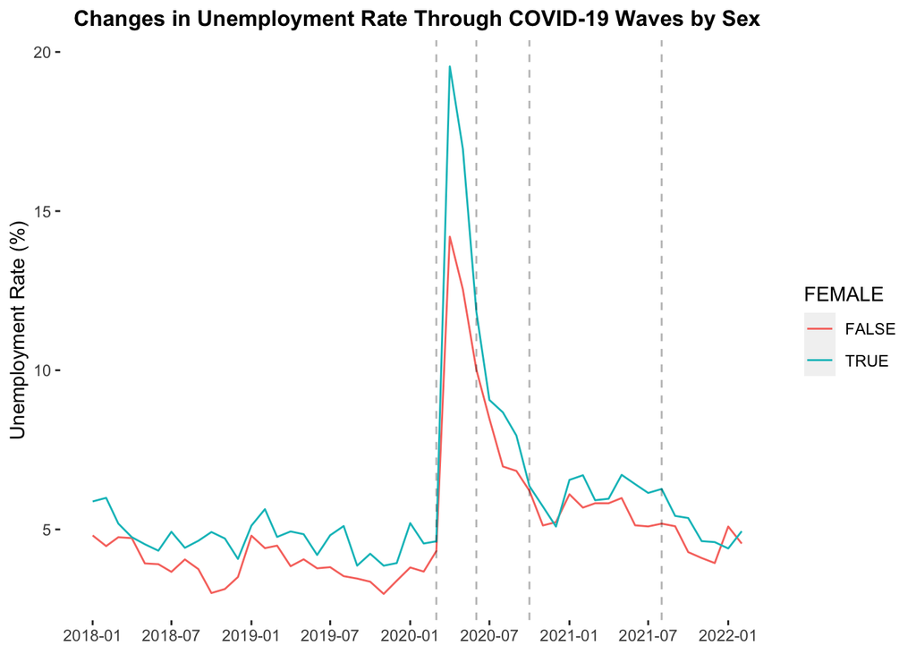

```r
fem_line <- ggplot(data=female_urate, aes(x=YEAR_MONTH, y=U_RATE, color=FEMALE)) + geom_line()
fem_line + scale_x_date(breaks = scales::breaks_pretty(13)) +
  geom_vline(alpha=0.3, xintercept = as.numeric(as.Date("2020-03-01")), linetype=2) +
  geom_vline(alpha=0.3, xintercept = as.numeric(as.Date("2020-06-01")), linetype=2) +
  geom_vline(alpha=0.3, xintercept = as.numeric(as.Date("2020-10-01")), linetype=2) +
  geom_vline(alpha=0.3, xintercept = as.numeric(as.Date("2021-08-01")), linetype=2) +
  theme(panel.background = element_blank(),
        plot.title = element_text(hjust = 0.5, size=12, face="bold"),
        axis.title.x = element_blank()) +
  labs(title = "Changes in Unemployment Rate Through COVID-19 Waves by Sex",
       y = "Unemployment Rate (%)")
```

## Race

```r
poc_data <- poc_urate %>%
  mutate(COVID_WAVES = case_when(YEAR_MONTH < "2020-03-01" ~ "Pre-COVID",
                                 YEAR_MONTH > "2020-02-01" & YEAR_MONTH < "2020-06-01" ~ "First Wave",
                                 YEAR_MONTH > "2020-05-01" & YEAR_MONTH < "2020-10-01" ~ "Second Wave",
                                 YEAR_MONTH > "2020-09-01" & YEAR_MONTH < "2021-08-01" ~ "Third Wave",
                                 YEAR_MONTH > "2021-07-01" ~ "Fourth Wave")) %>%

  mutate(COVID_WAVES = factor(COVID_WAVES,
                              levels = c("Pre-COVID",
                                         "First Wave",
                                         "Second Wave",
                                         "Third Wave",
                                         "Fourth Wave"))) %>%
  group_by(COVID_WAVES, POC) %>%
  summarise(mean(U_RATE))
poc_data %>%
  kbl() %>%
  kable_styling()
```

| COVID_WAVES | POC | mean(U_RATE) |
| --- | --- | --- |
| Pre-COVID | FALSE | 3.795070 |
| Pre-COVID | TRUE | 6.510870 |
| First Wave | FALSE | 11.293367 |
| First Wave | TRUE | 15.201662 |
| Second Wave | FALSE | 7.682582 |
| Second Wave | TRUE | 13.141795 |
| Third Wave | FALSE | 5.254865 |
| Third Wave | TRUE | 8.423024 |
| Fourth Wave | FALSE | 4.129773 |
| Fourth Wave | TRUE | 7.613757 |

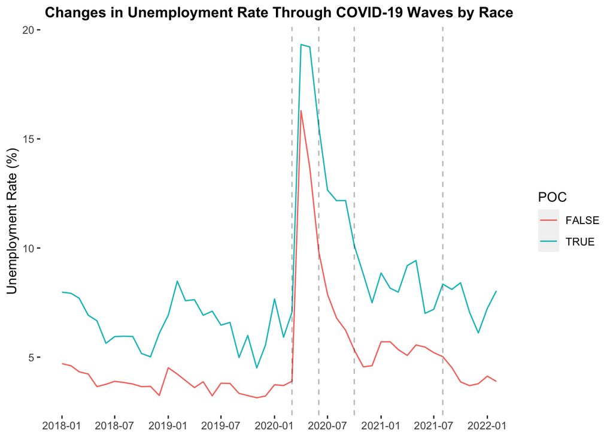

```r
poc_line <- ggplot(data=poc_urate, aes(x=YEAR_MONTH, y=U_RATE, color=POC)) + geom_line()
poc_line + scale_x_date(breaks = scales::breaks_pretty(13)) +
  geom_vline(alpha=0.3, xintercept = as.numeric(as.Date("2020-03-01")), linetype=2) +
  geom_vline(alpha=0.3, xintercept = as.numeric(as.Date("2020-06-01")), linetype=2) +
  geom_vline(alpha=0.3, xintercept = as.numeric(as.Date("2020-10-01")), linetype=2) +
  geom_vline(alpha=0.3, xintercept = as.numeric(as.Date("2021-08-01")), linetype=2) +
  theme(panel.background = element_blank(),
        plot.title = element_text(hjust = 0.5, size=12, face="bold"),
        axis.title.x = element_blank()) +
  labs(title = "Changes in Unemployment Rate Through COVID-19 Waves by Race",
       y = "Unemployment Rate (%)")
```

# Level of Education

```r
ba_data <- ba_urate %>%
  mutate(COVID_WAVES = case_when(YEAR_MONTH < "2020-03-01" ~ "Pre-COVID",
                                 YEAR_MONTH > "2020-02-01" & YEAR_MONTH < "2020-06-01" ~ "First Wave",
                                 YEAR_MONTH > "2020-05-01" & YEAR_MONTH < "2020-10-01" ~ "Second Wave",
                                 YEAR_MONTH > "2020-09-01" & YEAR_MONTH < "2021-08-01" ~ "Third Wave",
                                 YEAR_MONTH > "2021-07-01" ~ "Fourth Wave")) %>%

  mutate(COVID_WAVES = factor(COVID_WAVES,
                              levels = c("Pre-COVID",
                                         "First Wave",
                                         "Second Wave",
                                         "Third Wave",
                                         "Fourth Wave"))) %>%
  group_by(COVID_WAVES, BA_DEGREE) %>%
  summarise(mean(U_RATE))
ba_data %>%
  kbl() %>%
  kable_styling()
```

| COVID_WAVES | BA_DEGREE | mean(U_RATE) |
| --- | --- | --- |
| Pre-COVID | FALSE | 4.689859 |
| Pre-COVID | TRUE | 2.918328 |
| First Wave | FALSE | 12.334584 |
| First Wave | TRUE | 10.939549 |
| Second Wave | FALSE | 8.888954 |
| Second Wave | TRUE | 8.020043 |
| Third Wave | FALSE | 6.273169 |
| Third Wave | TRUE | 4.556114 |
| Fourth Wave | FALSE | 5.351134 |
| Fourth Wave | TRUE | 3.013945 |

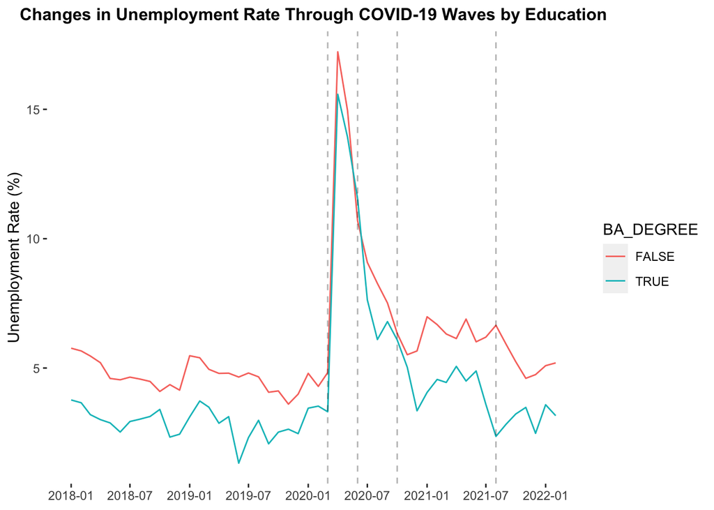

```r
ba_line <- ggplot(data=ba_urate, aes(x=YEAR_MONTH, y=U_RATE, color=BA_DEGREE)) + geom_line()
ba_line + scale_x_date(breaks = scales::breaks_pretty(13)) +
  geom_vline(alpha=0.3, xintercept = as.numeric(as.Date("2020-03-01")), linetype=2) +
  geom_vline(alpha=0.3, xintercept = as.numeric(as.Date("2020-06-01")), linetype=2) +
  geom_vline(alpha=0.3, xintercept = as.numeric(as.Date("2020-10-01")), linetype=2) +
  geom_vline(alpha=0.3, xintercept = as.numeric(as.Date("2021-08-01")), linetype=2) +
  theme(panel.background = element_blank(),
        plot.title = element_text(hjust = 0.5, size=12, face="bold"),
        axis.title.x = element_blank()) +
  labs(title = "Changes in Unemployment Rate Through COVID-19 Waves by Education",
       y = "Unemployment Rate (%)")
```